# Class 4 Notes and Exercises

## Task Set 2: Create simple charts

1. Create a histogram of arrival delay.

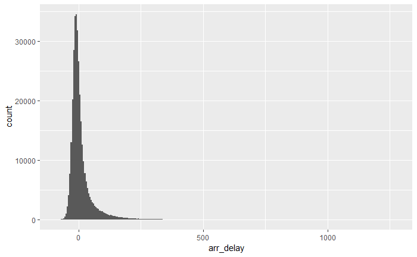

```r
flights %>%
  ggplot(data = ., mapping = aes(arr_delay)) +
  geom_histogram(binwidth=5)
```

2. Change the statistic for the histogram from the default of “count” to “density” and plot again.

```
Ignoring unknown parameters: binwidth, bins, pad
```

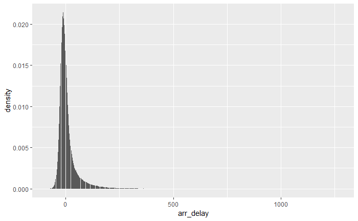

```r
flights %>%
  ggplot(data = ., mapping = aes(arr_delay)) +
  geom_histogram(stat = "density")
```

3. Run the following code to create a stacked column chart. Look through the documentation and examples for `geom_col()` on the tidyverse portal to fix the code below and create a chart where the bars for each origin are not stacked.

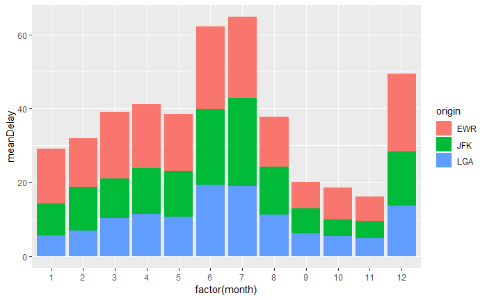

```r
flights %>%
    group_by(origin, month) %>%
    summarise(meanDelay = mean(dep_delay, na.rm = T)) %>%
    ggplot(aes(x = factor(month), y = meanDelay, fill = origin)) +
    geom_col()
```

4. Read the documentation for `geom_point()` to create a scatter plot that compares arrival delay with departure delay. How would you describe the relationship between the two variables?
5. Use the chunk below to group the data by `time_hour` and calculate the mean departure delay and pipe to a ggplot to create a line chart showing `time_hour` on the x-axis and the mean departure delay on the y-axis. Can you identify the spikes in the average delay? Which parts of this would you zoom into to get a better sense for the average delay?